# Reproducibility

## Reproducibility

What’s reproducibility?

A different analyst re-performs the analysis with the same code and the same data and obtains the same result.

## Reproducibility vs Repeatability vs Replicability

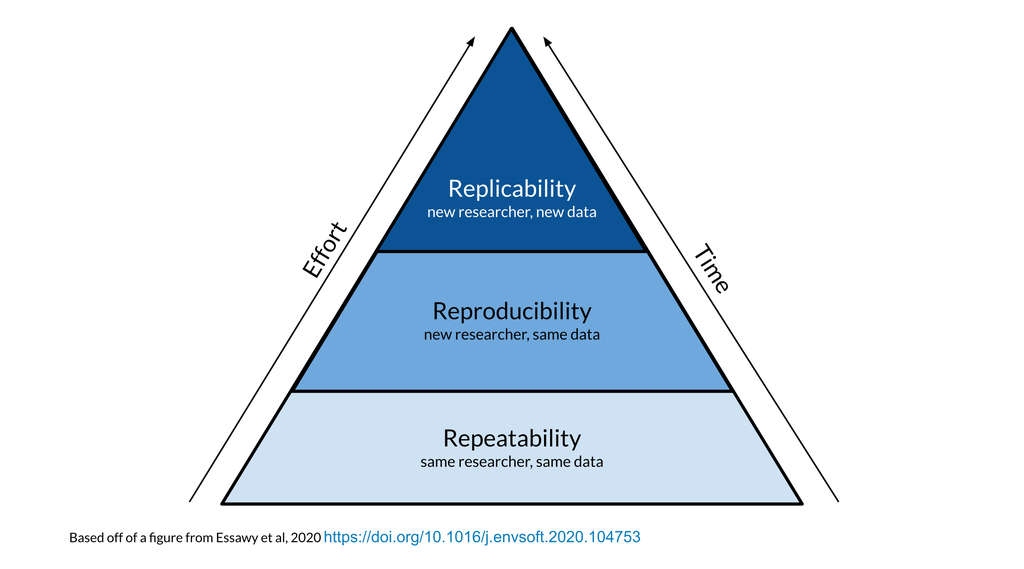

## Reproducibility

- Clean your environment regularly
- Use RMarkdown
- Check the knit of your RMarkdown regularly
- Tell your future self and others what you did!
- Print session info!

## RMarkdown

Clicking the knit button, will knit your document to create different types of reports. The default is html.

[figure not shown]

## Code Chunks

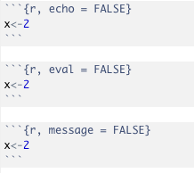

After knitting:  
1) **echo** - determines if your code should be shown or not  
- TRUE = code is **shown** (default)  
- FALSE = code is not shown (but might be run…depends on eval)  
2) **eval** - determines if your code should be evaluated (run) or not  
- TRUE = code is **run** (default)  
- FALSE = code is not run (but might be shown…depends on echo)  
3) **message** = FALSE -suppresses messages when your run your code

## RMarkdown syntax

Before:

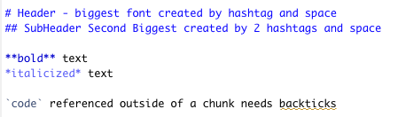

After knit:

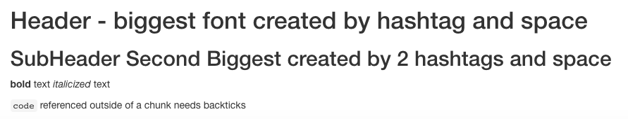

## RMarkdown syntax

Go to File > Help > Cheatsheets > R Markdown Cheatsheet

## Final Project

Specific guidelines and example on website

Turn in through CoursePlus:  
1) RMarkdown file  
2) html file

## Session Info

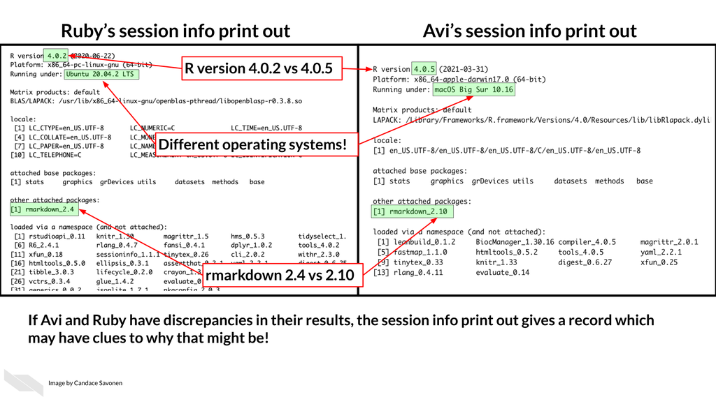

## DRY code

> “I hate code, and I want as little of it as possible in our product.” - Jack Diedrich

## More resources

These are just some quick tips, for more information:

- [The RMarkdown book](https://bookdown.org/yihui/rmarkdown/)
- [Jenny Bryan’s organizational strategies](https://www.stat.ubc.ca/~jenny/STAT545A/block19_codeFormattingOrganization.html).
- [Write efficient R code for science](https://www.earthdatascience.org/courses/earth-analytics/automate-science-workflows/write-efficient-code-for-science-r/).
- [Reproducibility in Cancer Informatics course](https://jhudatascience.org/Reproducibility_in_Cancer_Informatics/introduction.html)